# Prediction Power Heatmaps

The function `make_pred_plot()` visualizes the output from `prediction_power()` as a heatmap. Each cell shows an expected conditional entropy value, where lower values indicate stronger prediction power. Diagonal entries correspond to prediction using a single predictor, while off-diagonal entries correspond to prediction using pairs of predictors.

```r
library(netropy)
```

We first edit the node attributes so that all variables have finite categorical range spaces. The variables years and age are discretized into three categories.

```r
df_att <- lawdata[[4]]
att_var <- data.frame(
  status    = df_att$status - 1,
  gender    = df_att$gender,
  office    = df_att$office - 1,
  years     = ifelse(df_att$years <= 3, 0,
                ifelse(df_att$years <= 13, 1, 2)),
  age       = ifelse(df_att$age <= 35, 0,
                ifelse(df_att$age <= 45, 1, 2)),
  practice  = df_att$practice,
  lawschool = df_att$lawschool - 1
)
```

The first rows of the edited attribute data are:

```r
head(att_var)
```

```
##   status gender office years age practice lawschool
## 1      0      1      0     2   2        1         0
## 2      0      1      0     2   2        0         0
## 3      0      1      1     1   2        1         0
## 4      0      1      0     2   2        0         2
## 5      0      1      1     2   2        1         1
## 6      0      1      1     2   2        1         0
```

## Prediction Power

Assume we are interested in predicting `status`, which indicates whether a lawyer is an associate or a partner. We first compute the prediction power matrix:

```r
pred_status <- prediction_power("status", att_var)
pred_status
```

```
##           status gender office years   age practice lawschool
## status        NA     NA     NA    NA    NA       NA        NA
## gender        NA  0.695  0.818 0.404 0.514    0.871     0.800
## office        NA     NA  1.084 0.302 0.526    0.944     0.841
## years         NA     NA     NA 0.927 0.329    0.406     0.322
## age           NA     NA     NA    NA 1.007    0.683     0.617
## practice      NA     NA     NA    NA    NA    1.226     0.916
## lawschool     NA     NA     NA    NA    NA       NA     1.693
```

### Heatmap Visualization

The matrix can be visualized using `make_pred_plot()`:

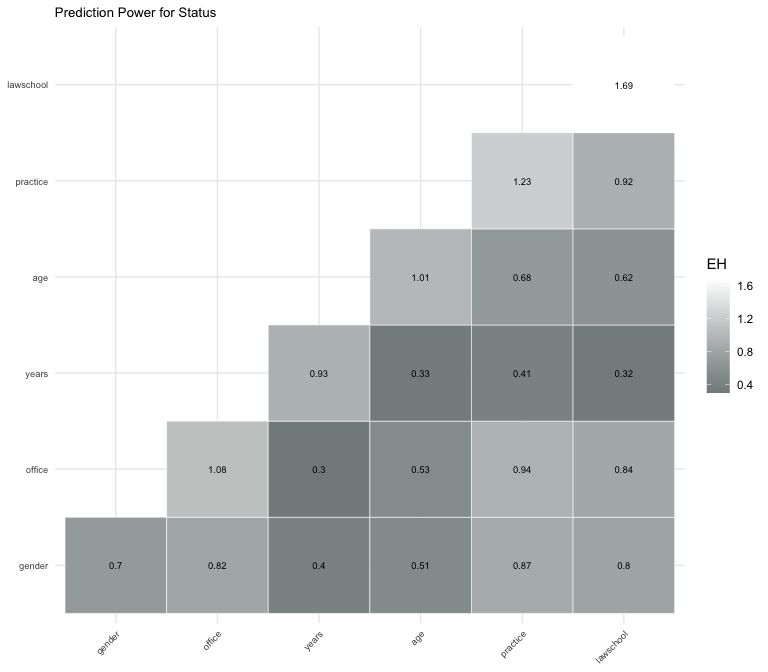

```r
make_pred_plot(pred_status, "Prediction Power for Status")
```

Darker cells indicate lower expected conditional entropy and therefore stronger prediction power. The diagonal entries show prediction based on one variable, while the off-diagonal entries show prediction based on pairs of variables.

### Changing Plot Colors

The colors can be adjusted using the `low` and `high` arguments. For example:

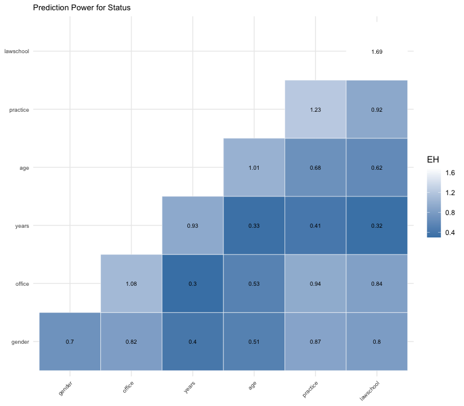

```r
make_pred_plot(
  pred_status,
  "Prediction Power for Status",
  low = "steelblue",
  high = "white"
)
```

### Changing Text Size

The size of the cell labels can be controlled with `text_size`:

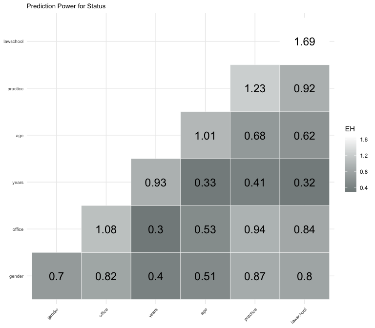

```r
make_pred_plot(
  pred_status,
  "Prediction Power for Status",
  text_size = 6
)
```

## References

> Frank, O., & Shafie, T. (2016). Multivariate entropy analysis of network data. *Bulletin of Sociological Methodology/Bulletin de Méthodologie Sociologique*, 129(1), 45-63. [link](https://doi.org/10.1177%2F0759106315615511)